# Investments

Week 2 – Lecture  
Utz Weitzel – VU Finance

**Note**

To run the R code in this file, first, open a new R script in RStudio (top dropdown menu: file/new file/R script). Then copy, one by one, the r code chunks in this file into that R script in RStudio. Use the little clipboard symbol at the right hand side of each code chunk to copy the code. Then, in RStudio, execute all the commands line by line with the ‘run’ command in the upper right corner of the source window. (Put your cursor on the line you want to execute before you click run.)

# Prepare session

## Tidyverse

In RStudio, open a project, or make a new one.

If you haven’t done so already, install the tidyverse package

```r
if(!require(tidyverse)) install.packages("tidyverse")
```

Then load the package. This is needed at the start of every new session.

```r
library(tidyverse)
options(dplyr.summarise.inform = FALSE)
```

**Note**

The options() command above suppresses some messages when grouping and summarizing, which are helpful for debugging but can also be distracting or clutter output. Setting this option to FALSE leads to a cleaner console output.

.

## Import data

For this section, we import dataset `df201` with *daily* return data from 2016 until 2022. `re` reports total equity returns `re` of several stocks indicated by `ticker`, and `rf` reports daily risk-free discounts that compound to a one-month T-bill rate over the number of trading days per month.

```r
df201 = read_csv("df201.csv", show_col_types=FALSE)

View(df201)
```

**Important**

Don’t forget to copy the file from Canvas to your project folder first.

.

## Excess returns

For all asset pricing models we need *excess* returns for both the stocks and the market

```r
dfrx1 = df201 |>
  mutate(rx = re-rf) |>
  mutate(rm = SP500-rf)

View(dfrx1)
```

As `rf` is now integrated into rx ad rm, we can clean up the dataframe

```r
dfrx2 = dfrx1 |>
  select(-re, -rf, -SP500, -month, -day) # not needed

View(dfrx2)
```

.

# Regression

## SIM

```r
dfAMZN = dfrx2 |> filter(ticker=="AMZN")

lm_AMZN = lm(rx ~ rm, data = dfAMZN)
```

**Tip**

Alternatively, we can subset the data directly in lm()

`lm_AMZN = lm(rx ~ rm, data = dfrx2, subset = (ticker == "AMZN"))`

.

## Results

The main results are saved in `lm_AMZN` . Let’s take a look at the structure

```r
str(lm_AMZN) # this is quite overwhelming
```

```r
coef(lm_AMZN)          # very little
confint(lm_AMZN)       # bare-bones confidence intervals
```

The command `summary()` computes and shows a more balanced overview

```r
summary(lm_AMZN) # can be saved: sum_AMZN = summary(lm_AMZN)
```

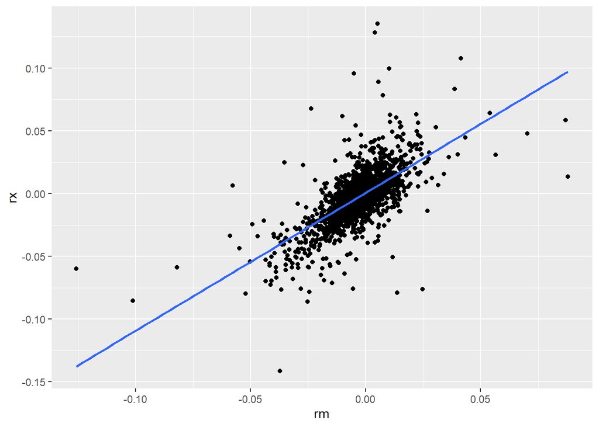

```r
ggplot(dfAMZN, aes(x = rm, y = rx)) +
  geom_point() +  # Plot the data points
  geom_smooth(method = "lm", se = FALSE)  # Add regression line
```

**Tip**

You can also call up other elements of lm_AMZN, for example:

```
resid(lm_AMZN)         # all residuals
fitted.values(lm_AMZN) # all fitted values
```

For a nicer display of tables with results in papers and theses you can use the package `stargazer`. It has many options and can get complex. A simpler variant for tables on the screen and quick reports is the package `broom`.

.

## Covariance

Let’s save the beta of Amazon

```r
beta_AMZN = coef(lm_AMZN)["rm"] # or: beta_AMZN=lm_AMZN$coefficients["rm"]
```

… and regress and save the beta of another stock (McDonald’s)

```r
lm_MCD = lm(rx ~ rm, data = dfrx2, subset = (ticker == "MCD"))

beta_MCD = coef(lm_MCD)["rm"]

summary(lm_MCD)
```

What is the covariance of the two stocks?

```r
rm_sd = sd(dfAMZN$rm) # market sd (same for AMZN & MCD)

Cov_AMZN_MCD = beta_AMZN * beta_MCD * rm_sd^2 # see Chapter 8

print(as.numeric(Cov_AMZN_MCD))
```

**Tip**

If you use `print(Cov_AMZN_MCD)`, R prints “rm” as ‘variable name’ next to the value of `Cov_AMZN_MCD`. This can be misleading. The functions `as.numeric()` and `unname()` prevent this.

.

## FF3 Factor

Let’s estimate a FF3 model with the three factors `MKT`, `SMB`, and `HML` (BTM) for AMZN until the end of 2019.

```r
lm_AMZN_FF3 = lm(rx ~ MKT + SMB + HML, data = dfrx2,
              subset = (year <= 2019 & ticker == "AMZN"))

summary(lm_AMZN_FF3)
```

**Note**

**Tip**

The long-short portfolio factors are downloaded from [Kenneth R. French’s data library](https://mba.tuck.dartmouth.edu/pages/faculty/ken.french/data_library.html) reaching back to 1926.

.

# 1 Event, 1 Stock

## Corona month

In late February 2020, the stock market began showing volatility and declined as COVID-19 cases started to spread outside China, raising global pandemic fears. But the real price adjustments happened in March 2020:

- **March 9, 2020:** The Dow Jones Industrial Average (DJIA) fell by more than 2,000 points, marking one of its worst single-day point drops in history at that time.
- **March 11, 2020:** The World Health Organization (WHO) officially declared COVID-19 a pandemic.
- **March 12, 2020:** Known as *“Black Thursday”*, the DJIA fell by 2,353 points, which was its worst one-day percentage drop since the 1987 stock market crash.
- **March 16, 2020:** The DJIA plummeted nearly 3,000 points as widespread lock-downs and travel bans began to be implemented across the United States and many parts of the world.

.

## Estimate SIM

We start with a single-factor *market model* and use all returns until the end of 2019 as *estimation window* (referred to as *historic* data) to estimate the intercept and beta of **SIM/CAPM**

```r
lm_AMZN_hist = lm(rx ~ rm, data = dfAMZN, subset = (year <= 2019))

coef(lm_AMZN_hist)
confint(lm_AMZN_hist) # or summary(lm_AMZN_hist)
```

.

## Predict SIM

Using the historic model `lm_hist_AMZN`, we predict the stock returns for all dates in the sample, that is both in-sample (<=2019) and out-of-sample (>2019). This includes our *event window*: the ‘Corona month’ March 2020. We save the predicted returns as `rx_pred` in `dfAMZN`

```r
dfAMZN$rx_pred = predict(lm_AMZN_hist, newdata = dfAMZN)

View(dfAMZN)
```

.

## AR SIM

The **abnormal return (AR)** is the prediction error, i.e. the difference between the actual (observed) and the predicted (estimated) returns: actual - predicted

```r
dfAMZN = dfAMZN |> mutate(ra = rx - rx_pred)

View(dfAMZN)
```

Let’s take a look at AMZN’s daily abnormal returns in March 2020

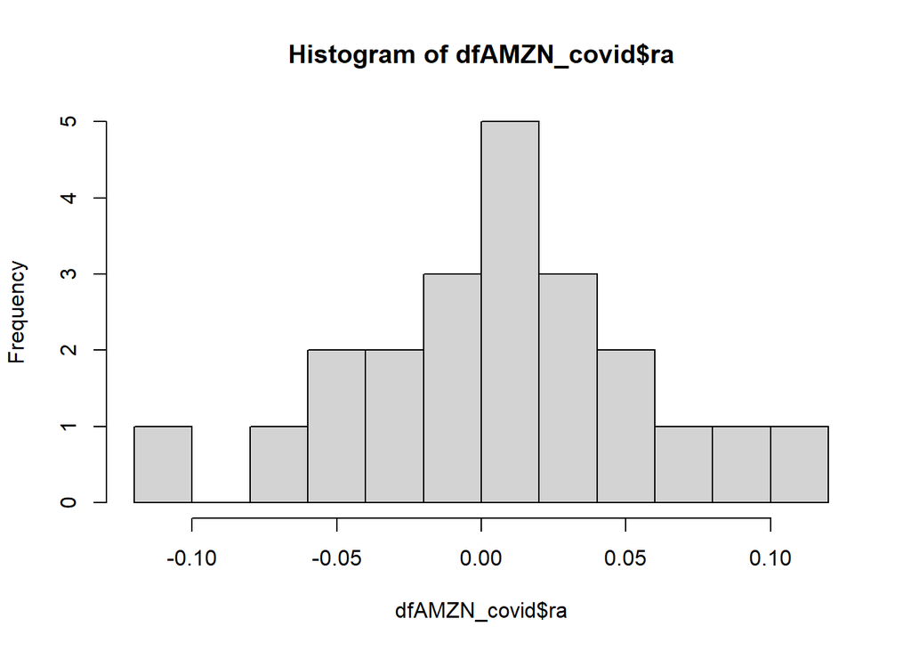

```r
dfAMZN_covid = dfAMZN |>
  filter(date>=as.Date("2020-03-01") & date<as.Date("2020-04-01"))

hist(dfAMZN_covid$ra, breaks=10)
```

**Note**

The command `as.Date()` makes sure that R converts character strings into Date objects. If the variable `date` is already a Date object (you can check this with `str(dfAMZN)`), then the filter command also works with `filter(date>="2020-03-01" & date<"2020-04-01")`

.

## CAR SIM

To see the dynamics in March 2020, we accumulate the daily ARs into equally many CARs

```r
dfAMZN_covid = dfAMZN_covid |>
  arrange(date) |> # just to be sure
  mutate(car_ra = cumsum(ra)) |> # CARs abnormal return
  mutate(car_rm = cumsum(rm))    # CARs market return

View(dfAMZN_covid)
```

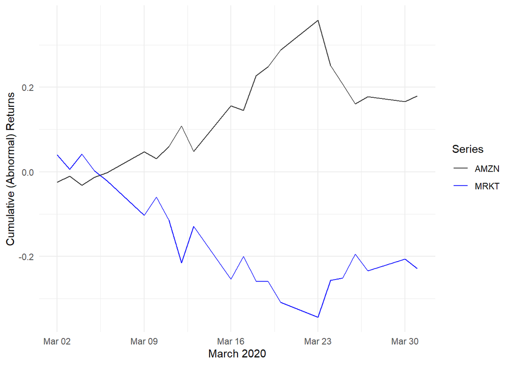

```r
ggplot(dfAMZN_covid) +
  geom_line(aes(x = date, y = car_ra, color = "AMZN")) +
  geom_line(aes(x = date, y = car_rm, color = "MRKT")) +
  labs(x = "March 2020", y = "Cumulative (Abnormal) Returns", color = "Series") +
  scale_color_manual(values = c("AMZN" = "grey20", "MRKT" = "blue")) +
  theme_minimal()
```

.

## AR/CAR Mkt-adj

The simplest “prediction” model is the **market-adjusted model** which assumes a beta of 1. With beta=1, the market’s excess return proxies for the stock’s “predicted” return. Hence, the abnormal return is the stock’s actual excess return minus the market’s excess return

```r
dfAMZN_covid = dfAMZN_covid |>
  mutate(rmadj = rx - rm) |>
  mutate(car_rmadj = cumsum(rmadj))
```

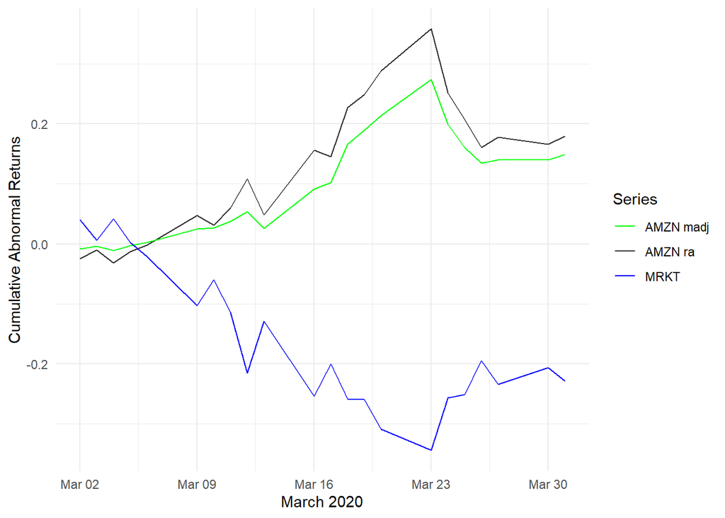

```r
ggplot(dfAMZN_covid) +
  geom_line(aes(x = date, y = car_ra, color = "AMZN ra")) +
  geom_line(aes(x = date, y = car_rmadj, color = "AMZN madj")) +
  geom_line(aes(x = date, y = car_rm, color = "MRKT")) +
  labs(x = "March 2020", y = "Cumulative Abnormal Returns", color = "Series") +
  scale_color_manual(values = c("AMZN ra" = "grey20", "AMZN madj" = "green", "MRKT" = "blue")) +
  theme_minimal()
```

.

## AR/CAR FF3

For the *market model*, we can take any single- or multi-factor asset pricing model (e.g., SIM/CAPM, APT, FF3, FFC, …) and compute abnormal returns as prediction errors of the estimated returns of that model.

Above we already estimated the FF3-Factor model of AMZN until the end of 2019 (estimation window), and saved it as `lm_AMZN_FF3`. Using the parameters of this model, we can predict AMZN’s returns for March 2020 (event window) and compute ARs and CARs

```r
dfAMZN_covid$rx_FF3 = predict(lm_AMZN_FF3, newdata = dfAMZN_covid)

dfAMZN_covid = dfAMZN_covid |>
  mutate(rFF3 = rx - rx_FF3) |>
  mutate(car_rFF3 = cumsum(rFF3))
```

**Note**

Note that we now predict the stock returns directly into the dataframe `dfAMZN_covid` that only contains the March 2020 values. Previously, we predicted the returns into the dataframe `dfAMZN`, which included both the historic returns *before* 2020 and the returns *after* 2019.

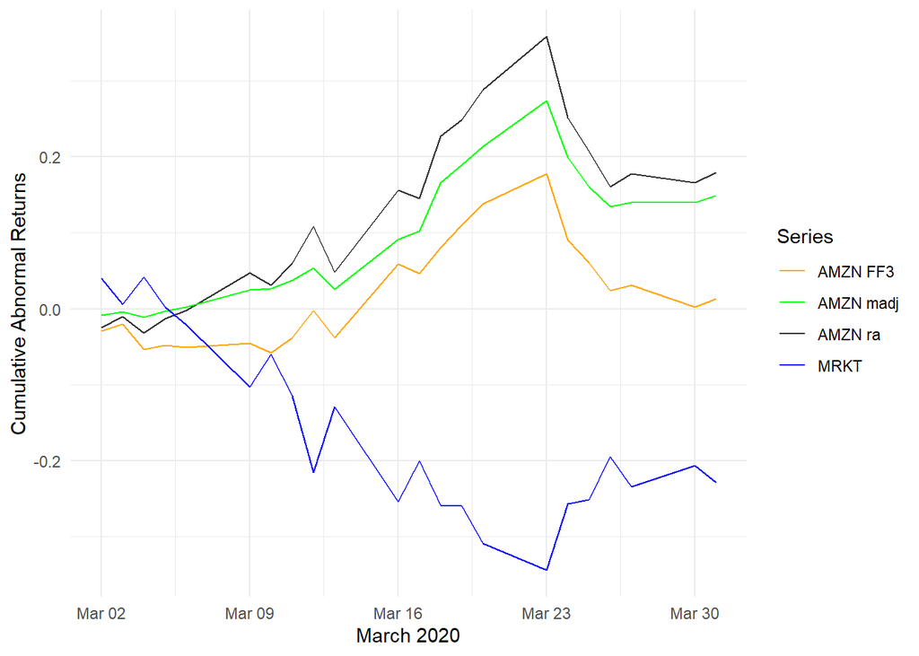

```r
ggplot(dfAMZN_covid) +
  geom_line(aes(x = date, y = car_ra, color = "AMZN ra")) +
  geom_line(aes(x = date, y = car_rmadj, color = "AMZN madj")) +
  geom_line(aes(x = date, y = car_rFF3, color = "AMZN FF3")) +
  geom_line(aes(x = date, y = car_rm, color = "MRKT")) +
  labs(x = "March 2020", y = "Cumulative Abnormal Returns", color = "Series") +
  scale_color_manual(values = c("AMZN ra" = "grey20", "AMZN madj" = "green", "AMZN FF3" = "orange", "MRKT" = "blue")) +
  theme_minimal()
```

.

## T-test CAR

For Patell’s (1976) t-statistic, $t = \frac{CAR}{\hat{\sigma}_{AR} \cdot \sqrt{D \cdot \left(1 + \frac{1}{T} \right)}}$, we need the CAR, the standard deviation of the firm’s ARs in the estimation window, and the number of ARs in the estimation window (T) as well as in the event window (D).

We take the ARs of the SIM/CAPM and use 2019 as the **estimation window**

```r
dfAMZN_est = dfAMZN |>

  # estimation window
  filter(year == 2019) |>

  # compute sd and n of ra
  summarize(sd   = sd(ra),
            sd_n = sum(!is.na(ra))) # or n=n() if no ra is missing

# save as values
sd   = as.double(dfAMZN_est$sd)
sd_n = as.integer(dfAMZN_est$sd_n)

print(sd)
print(sd_n)
```

**Note**

Extracting values from a dataframe is lengthy in the tidyverse. This is where base R shines, which uses only two lines for the same result:

```
sd   = sd(dfAMZN$ra[dfAMZN$year == 2019])
sd_n = sum(!is.na(dfAMZN$ra[dfAMZN$year == 2019]))
```

The **event window** is March 2020

```r
dfAMZN_evt = dfAMZN_covid |> # contains only March 2020 observations

  # compute CAR and n
  summarize(car   = sum(ra),
            car_n = sum(!is.na(ra)))

# save as values
car   = as.double(dfAMZN_evt$car)
car_n = as.integer(dfAMZN_evt$car_n)

print(car)
print(car_n)
```

**Important**

We use the function `sum()` for CARs and not, as previously, `cumsum()`. This is because we are not interested in plotting the day-by-day development of one stock’s abnormal returns. We need a single `car` variable that aggregates the abnormal returns over the whole event window. Note that the value of `car` is equal to the value of `car_ra` (which we computed in `dfAMZN_covid` with `cumsum(ra)`) on the very last day of the month March 2020.

Patell’s (1976) **t-statistic** is then

```r
t_stat = car / (sd * sqrt(car_n*(1+1/sd_n))) # t-statistic

p_val = 2 * pt(-abs(t_stat), df = sd_n-1)    # p-value of two-sided test

print(t_stat)
print(p_val)
```

**Note**

As we are estimating the variance from the estimation window, the degrees of freedom (df=T-1) in function `pt()` come from that variance estimate, which has `sd_n` observations and `sd_n-1` df.

.

# 1 Event, N Stocks

For this section, we import dataset `df202` with *daily* abnormal returns estimated with the FF3 model.

The estimation window was 100 trading days (at least 70 days with trading data), with a gap of 50 trading days before the event date.

The event date `evtdate` is March 11, 2020, where the WHO officially declared COVID-19 a pandemic.

Per stock in `ticker`, the data set contains total returns `re` and FF3 abnormal returns `ra` per event day `evtday` from 10 trading days before to 10 trading days after `evtdate`.

```r
df202 = read_csv("df202.csv", show_col_types=FALSE)

View(df202)
```

See all tickers

```r
print(unique(df202$ticker))
```

**Note**

The data set also contains some sector dummies and the log of the market capitalization in April 2024 (as a rough proxy for firm size). Sectors and market cap are taken from [companiesmarketcap.com](https://companiesmarketcap.com/).

.

## ARs across stocks

Let’s inspect the daily abnormal returns across all stocks.

```r
ar_analysis = df202 |>
  group_by(evtday) |>
  summarize(
    mean_ra = mean(ra, na.rm = TRUE),       # mean ar
    sem = sd(ra, na.rm = TRUE) / sqrt(n()), # std error
    n = n()) |>
  mutate(
    lower_ci = mean_ra - qt(0.975, df = n-1) * sem, # Lower bound 95% CI
    upper_ci = mean_ra + qt(0.975, df = n-1) * sem) # Upper bound 95% CI

View(ar_analysis)
```

**Note**

The R function `qt()` returns quantiles (cutoff values) of the Student’s t-distribution. Basically, it is the inverse of the cumulative distribution function (CDF).

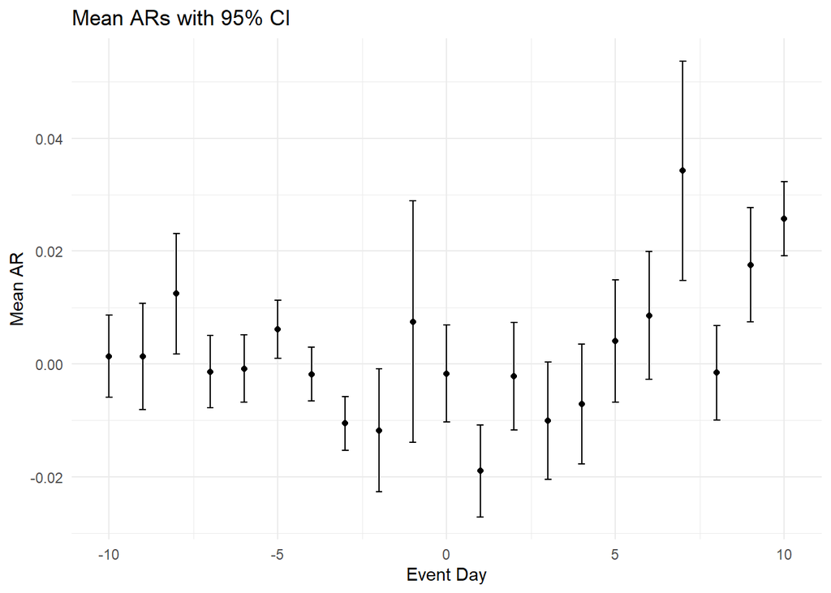

```r
ggplot(ar_analysis, aes(x = evtday, y = mean_ra)) +
  geom_point() +
  geom_errorbar(aes(ymin = lower_ci, ymax = upper_ci), width = 0.2) +
  labs(x = "Event Day", y = "Mean AR", title = "Mean ARs with 95% CI") +
  theme_minimal()
```

.

## CAR 21 days

```r
dfcar21 = df202 |>
  group_by(ticker) |> # as we know that there is only one event per ticker
  mutate(car21 = sum(ra, na.rm=T)) |> # sum all ARs to one CAR
  filter(evtday==0) |> # keep one observation per ticker
  select(-re, -Name, -evtdate) # some cleanup

View(dfcar21)
```

```r
hist(dfcar21$car21)
```

.

## CAR 05 days

And what about CARs around a relatively short event window of +/-2 days (5 days in total)?

```r
dfcar05 = df202 |>
  filter(evtday>=-2 & evtday<=2) |> # +/-2 days around evtday==0
  group_by(ticker) |>
  mutate(car05 = sum(ra, na.rm=T)) |>
  filter(evtday==0) |>
  select(-re, -Name, -evtdate)

View(dfcar05)
```

```r
hist(dfcar05$car05)
```

.

## OLS sectors

Let’s see what happened to the CARs in specific sectors. Instead of running regressions for each sector individually, we can also use sector dummies as explanatory variables and see whether they have predictive value. We drop the pharma sector as reference category (largest sector in data).

```r
lm_car05 = lm(car05 ~ airline + ecommerce + restaurant + software, data = dfcar05)

summary(lm_car05)
```

```r
lm_car21 = lm(car21 ~ airline + ecommerce + restaurant + software, data = dfcar21)

summary(lm_car21)
```

**Tip**

DIY: rerun the regressions, but include logsize as another control variable. Do the results change qualitatively? Why / Why not? (Hint: recall the factors that are included in the FF3 estimations.)